### Practical Machine Learning Course Project Report

### Synoposis

In this course project, the goal is to use data from accelerometers on the belt, forearm, arm and dumbell of 6 participants, to predict the manner in which they did the barbell lifts. Prediction models were built using the training data set to predict the “classe” variable. Based on the cross validation and out-of-sample error, the model built with random forest algorithm performed the best and was selected. This prediction model was used to predict the 20 different test cases.

### Data Processing

The training data and test data for this proeject are downloaded from the course website, https://d396qusza40orc.cloudfront.net/predmachlearn/pml-training.csv, https://d396qusza40orc.cloudfront.net/predmachlearn/pml-testing.csv. The weight lifting excercies dataset is from Velloso et al, 2013 [1].

#### Reading in the data

The training and test data were read from .csv files. The data is comma-seperated format with fields that are blank, “NA” and “#DIV/0!” as missing values.

```r
library(knitr)
trainingData <- read.csv("pml-training.csv", header=TRUE,na.strings=c("","NA","#DIV/0!"))
testData <- read.csv("pml-testing.csv", header=TRUE,na.strings=c("","NA","#DIV/0!"))
```

#### Preprocessing the data

In the datasets, the columns with at least a missing value were ignored. The first 7 columns: “X”, “user_name”, “raw_timestamp_part_1”, “raw_timestamp_part_2”, “cvtd_timestamp”, “new_window” and “num_window” were ignored due to the irrelevancy to the classificaiton.

```r
trainingData <- trainingData[, colSums(is.na(trainingData)) == 0]
testData <- testData[, colSums(is.na(testData)) == 0]
trainingData <- trainingData[,-c(1:7)]
testData <- testData[,-c(1:7)]
dim(trainingData)
```

```
## [1] 19622    53
```

```r
# Set an overal random seed.
set.seed(32343)
```

#### Cross-validation and out-of-sample error

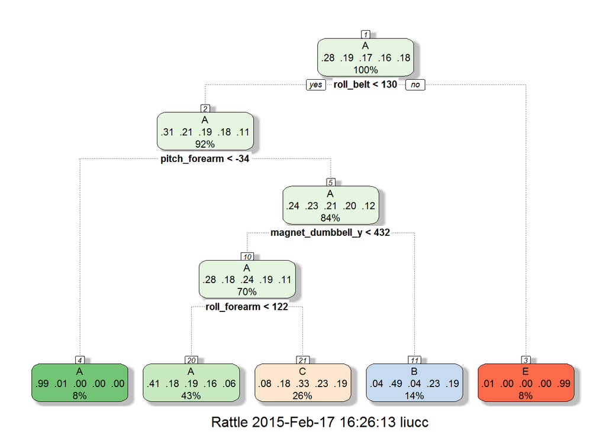

```r
library(lattice)
library(ggplot2)
library(caret)
### Split training data to training/testing for one time cross-validation
inTrain <- createDataPartition(y=trainingData$classe, p=0.75, list=FALSE)
training <- trainingData[inTrain,]
testing <- trainingData[-inTrain,]

### predicting with Decision Trees
library(rpart)
library(rattle)
library(rpart.plot)
modelFit1 <- train(classe ~., data=training, method="rpart")
fancyRpartPlot(modelFit1$finalModel)
```

```r
predictions1 <- predict(modelFit1,newdata=testing)
confusionMatrix(predictions1,testing$classe)
```

```
## Confusion Matrix and Statistics
##
##           Reference
## Prediction    A    B    C    D    E
##          A 1255  383  382  362  130
##          B   25  327   31  134  114
##          C  112  239  442  308  236
##          D    0    0    0    0    0
##          E    3    0    0    0  421
##
## Overall Statistics
##
##                Accuracy : 0.499
##                  95% CI : (0.484, 0.513)
##     No Information Rate : 0.284
##     P-Value [Acc > NIR] : <2e-16
##
##                   Kappa : 0.345
##  Mcnemar's Test P-Value : NA
##
## Statistics by Class:
##
##                      Class: A Class: B Class: C Class: D Class: E
## Sensitivity             0.900   0.3446   0.5170    0.000   0.4673
## Specificity             0.642   0.9231   0.7790    1.000   0.9993
## Pos Pred Value          0.500   0.5182   0.3306      NaN   0.9929
## Neg Pred Value          0.941   0.8544   0.8842    0.836   0.8929
## Prevalence              0.284   0.1935   0.1743    0.164   0.1837
## Detection Rate          0.256   0.0667   0.0901    0.000   0.0858
## Detection Prevalence    0.512   0.1287   0.2726    0.000   0.0865
## Balanced Accuracy       0.771   0.6339   0.6480    0.500   0.7333
```

```r
error1 <- 1 - confusionMatrix(predictions1,testing$classe)$overall[[1]]

### predicting with Random Forest
library(randomForest)
modelFit2 <- randomForest(classe ~ ., data=training, importance=TRUE, ntrees=10)
predictions2 <- predict(modelFit2,newdata=testing)
confusionMatrix(predictions2,testing$classe)
```

```
## Confusion Matrix and Statistics
##
##           Reference
## Prediction    A    B    C    D    E
##          A 1394    8    0    0    0
##          B    0  939   10    0    0
##          C    0    2  845    8    2
##          D    0    0    0  795    1
##          E    1    0    0    1  898
##
## Overall Statistics
##
##                Accuracy : 0.993
##                  95% CI : (0.991, 0.995)
##     No Information Rate : 0.284
##     P-Value [Acc > NIR] : <2e-16
##
##                   Kappa : 0.991
##  Mcnemar's Test P-Value : NA
##
## Statistics by Class:
##
##                      Class: A Class: B Class: C Class: D Class: E
## Sensitivity             0.999    0.989    0.988    0.989    0.997
## Specificity             0.998    0.997    0.997    1.000    1.000
## Pos Pred Value          0.994    0.989    0.986    0.999    0.998
## Neg Pred Value          1.000    0.997    0.998    0.998    0.999
## Prevalence              0.284    0.194    0.174    0.164    0.184
## Detection Rate          0.284    0.191    0.172    0.162    0.183
## Detection Prevalence    0.286    0.194    0.175    0.162    0.184
## Balanced Accuracy       0.999    0.993    0.993    0.994    0.998
```

```r
error2 <- 1 - confusionMatrix(predictions2,testing$classe)$overall[[1]]
```

The model built using “rpart” gives an expected out-of-sample error of 0.5014, and the model built using “randomForest” gives an expected out-of-sample error of 0.0067, which is smaller and close to zero. Therefore, the random forest model was selected to predict the 20 cases in the test data set.

```r
### predicting the test set
answers <- predict(modelFit2,newdata=testData)
answers
```

```
##  1  2  3  4  5  6  7  8  9 10 11 12 13 14 15 16 17 18 19 20
##  B  A  B  A  A  E  D  B  A  A  B  C  B  A  E  E  A  B  B  B
## Levels: A B C D E
```

```r
pml_write_files = function(x){
  n = length(x)
  for(i in 1:n){
    filename = paste0("problem_id_",i,".txt")
    write.table(x[i],file=filename,quote=FALSE,row.names=FALSE,col.names=FALSE)
  }
}

pml_write_files(answers)
```

The prediction results each in a file were submitted to the programming assignment for automated grading.

### References

[1] Velloso, E.; Bulling, A.; Gellersen, H.; Ugulino, W.; Fuks, H. Qualitative Activity Recognition of Weight Lifting Exercises. Proceedings of 4th International Conference in Cooperation with SIGCHI (Augmented Human ’13) . Stuttgart, Germany: ACM SIGCHI, 2013